# IA 2

## Individual Assignment #2: ARIMA Lab.

#### Due: Nov. 23 before class time

#### (40 points)

The file titled **US Electricity.csv** includes a time series index compiled by the US Federal Reserve representing total fossil-fuel US electricity generation by all utilities from January 1939 through October 2021.

In the following code box we read the CSV file and set up the data as a *tsibble* and then we plot it and subset it to examine it.

```r
library(fpp3)
library(tseries)
```

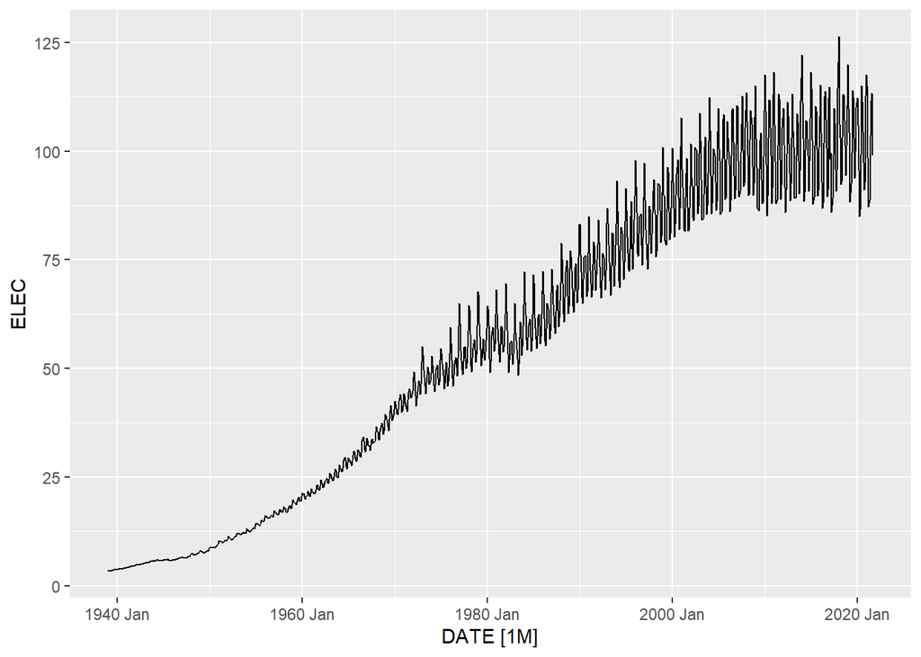

```r
rm(list=ls())

D <- read.csv("US Electricity.csv") %>%
  mutate(DATE = yearmonth(DATE)) %>%
  as_tsibble(index = DATE)

D %>% autoplot(ELEC)
```

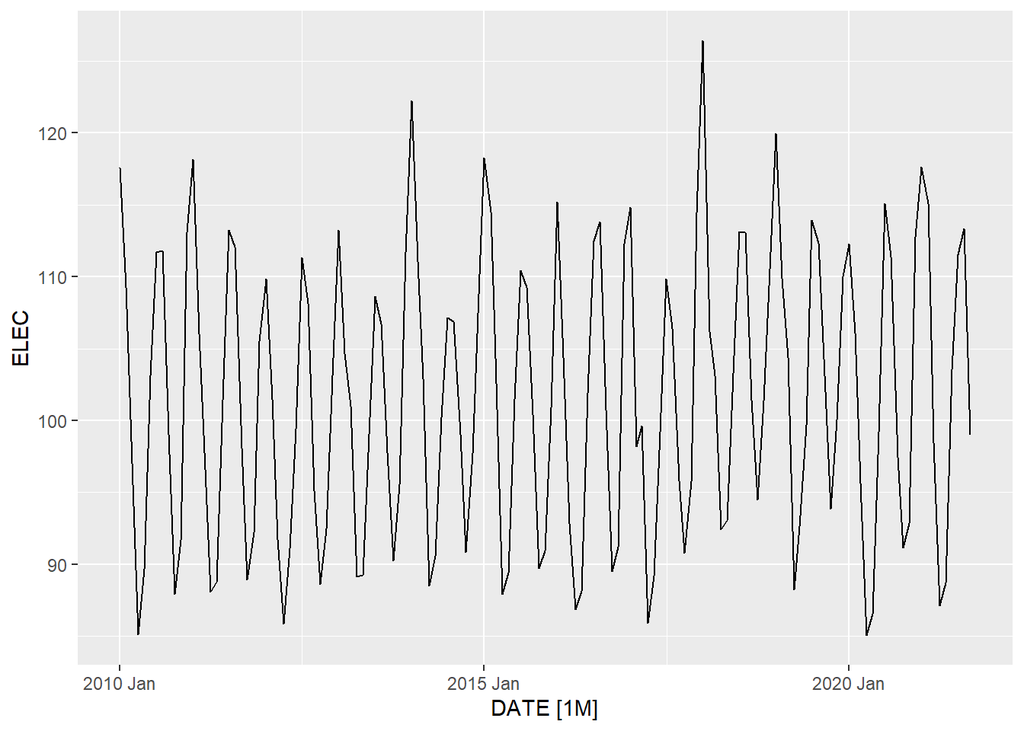

```r
DR <- D %>% filter(DATE >= yearmonth("2010 Jan"))

DR %>% autoplot(ELEC)
```

We are interested in developing a two-year long monthly forecast (24 months) for the national electricity production requirements.

1. Examine the stationarity of the **ELEC** time series in the reduced **DR** data, examine also the corresponding ACF and PACF diagrams and propose three plausible ARIMA models to fit the data.

```r
DR %>%
  mutate(diff.P = difference(ELEC),
         diff2.P = difference(diff.P),
         diff3.P = difference(diff2.P),
         diff4.P = difference(diff3.P)) -> DR2

DR2 %>% features(ELEC, unitroot_kpss)
```

| kpss_stat | kpss_pvalue |
| --- | --- |
| 0.2218263 | 0.1 |

```r
DR2 %>% features(diff.P, unitroot_kpss)
```

| kpss_stat | kpss_pvalue |
| --- | --- |
| 0.04720146 | 0.1 |

```r
DR2 %>% features(diff2.P, unitroot_kpss)
```

| kpss_stat | kpss_pvalue |
| --- | --- |
| 0.06071587 | 0.1 |

```r
DR2 %>% features(diff3.P, unitroot_kpss)
```

| kpss_stat | kpss_pvalue |
| --- | --- |
| 0.04470052 | 0.1 |

```r
DR2 %>% features(diff4.P, unitroot_kpss)
```

| kpss_stat | kpss_pvalue |
| --- | --- |
| 0.02299115 | 0.1 |

```r
DR2 %>% features(ELEC, unitroot_ndiffs)
```

| ndiffs |
| --- |
| 0 |

```r
DR2$ELEC %>% adf.test()
```

```
##
##  Augmented Dickey-Fuller Test
##
## data:  .
## Dickey-Fuller = -3.8581, Lag order = 5, p-value = 0.01823
## alternative hypothesis: stationary
```

```r
DR2$diff.P %>%
  na.omit() %>%
  adf.test()
```

```
##
##  Augmented Dickey-Fuller Test
##
## data:  .
## Dickey-Fuller = -7.3944, Lag order = 5, p-value = 0.01
## alternative hypothesis: stationary
```

```r
DR2$diff2.P %>%
  na.omit() %>%
  adf.test()
```

```
##
##  Augmented Dickey-Fuller Test
##
## data:  .
## Dickey-Fuller = -14.314, Lag order = 5, p-value = 0.01
## alternative hypothesis: stationary
```

```r
DR2$diff3.P %>%
  na.omit() %>%
  adf.test()
```

```
##
##  Augmented Dickey-Fuller Test
##
## data:  .
## Dickey-Fuller = -18.055, Lag order = 5, p-value = 0.01
## alternative hypothesis: stationary
```

```r
DR2$diff4.P %>%
  na.omit() %>%
  adf.test()
```

```
##
##  Augmented Dickey-Fuller Test
##
## data:  .
## Dickey-Fuller = -17.57, Lag order = 5, p-value = 0.01
## alternative hypothesis: stationary
```

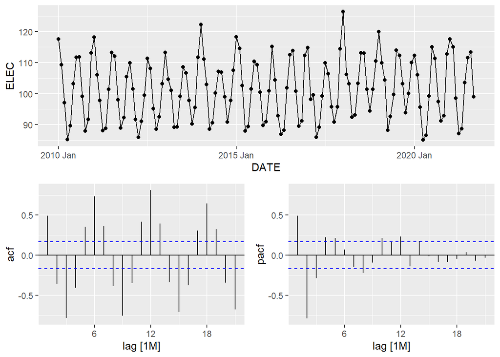

```r
DR2 %>% gg_tsdisplay(ELEC, plot_type = "partial")
```

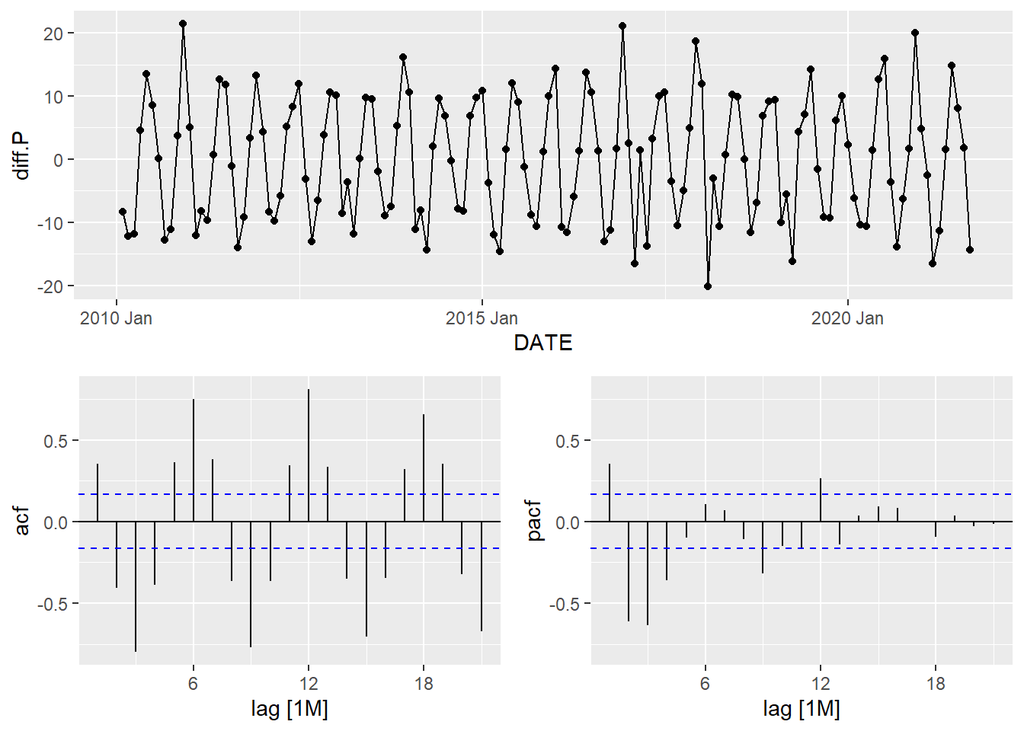

```r
DR2 %>% gg_tsdisplay(diff.P, plot_type = "partial")
```

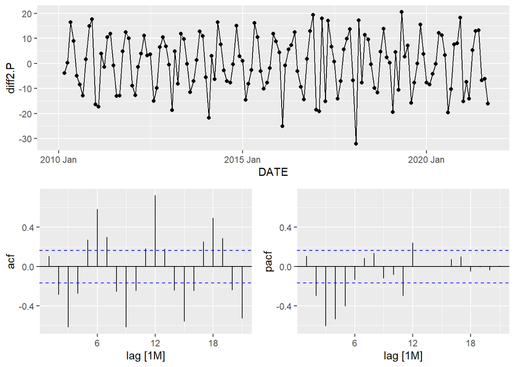

```r
DR2 %>% gg_tsdisplay(diff2.P, plot_type = "partial")
```

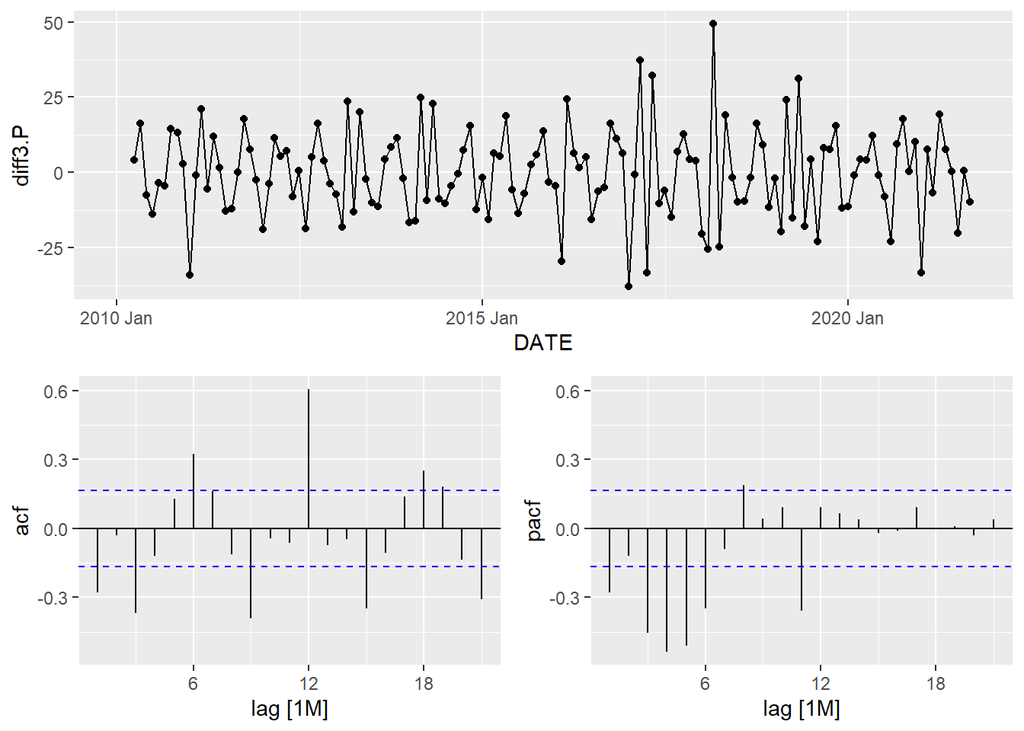

```r
DR2 %>% gg_tsdisplay(diff3.P, plot_type = "partial")
```

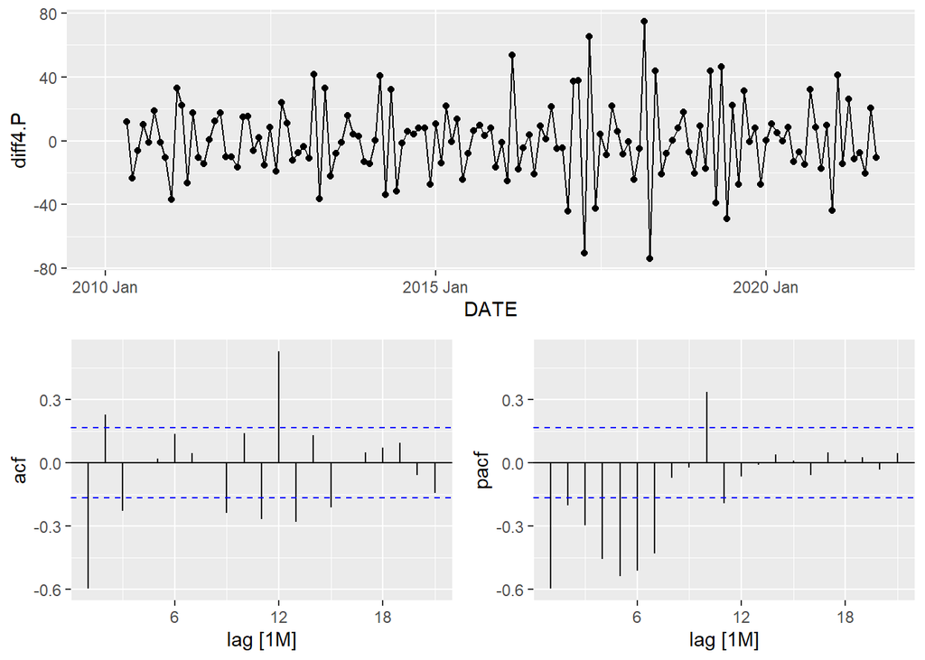

```r
DR2 %>% gg_tsdisplay(diff4.P, plot_type = "partial")
```

According to the result, we need to difference the data 0 times before fitting the model. Difference 0, 1, 2 are likely to be stationary.

2. Using **fable** fit the following five models to the **DR** data: (i)-(iii) the three models you propose in (1), (iv) the automatically selected model by the ARIMA() functionn, and (v) the automatically selected model by the ETS() function. Report the name/order of each model and the corresponding AICc and BIC.

```r
m <- DR2 %>% model(m1 = ARIMA(ELEC),
                 m2 = ARIMA(ELEC ~ pdq(0,1,2)),
                 m3 = ARIMA(ELEC ~ pdq(2,0,1)),
                 m4 = ETS(ELEC),
                 m5 = ARIMA(ELEC ~ pdq(1,0,2)))
```

3. Examine the residuals of all the models using the Ljung-Box test and the **gg_tsresiduals()** function. Is there a validity problem with any of the models?

```r
m %>% augment() %>%
  features(.resid, ljung_box, lag = 10)
```

| .model | lb_stat | lb_pvalue |
| --- | --- | --- |
| m1 | 9.004264 | 0.53169896 |
| m2 | 11.305816 | 0.33419377 |
| m3 | 8.222738 | 0.60709021 |
| m4 | 20.407202 | 0.02562816 |
| m5 | 7.755899 | 0.65266655 |

```r
m %>% select(m1) %>% report()
```

```
## Series: ELEC
## Model: ARIMA(1,0,0)(2,1,0)[12]
##
## Coefficients:
##          ar1     sar1     sar2
##       0.3757  -0.3375  -0.4386
## s.e.  0.0877   0.0834   0.0870
##
## sigma^2 estimated as 10.76:  log likelihood=-337.76
## AIC=683.53   AICc=683.85   BIC=694.97
```

```r
m %>% select(m2) %>% report()
```

```
## Series: ELEC
## Model: ARIMA(0,1,2)(1,1,0)[12]
##
## Coefficients:
##           ma1      ma2     sar1
##       -0.4752  -0.2519  -0.2341
## s.e.   0.0869   0.1002   0.0893
##
## sigma^2 estimated as 14.4:  log likelihood=-351.46
## AIC=710.93   AICc=711.25   BIC=722.33
```

```r
m %>% select(m3) %>% report()
```

```
## Series: ELEC
## Model: ARIMA(2,0,1)(2,1,0)[12]
##
## Coefficients:
##          ar1      ar2      ma1     sar1     sar2
##       0.8858  -0.1378  -0.5357  -0.3386  -0.4353
## s.e.  0.6406   0.2780   0.6304   0.0837   0.0870
##
## sigma^2 estimated as 10.88:  log likelihood=-337.4
## AIC=686.8   AICc=687.49   BIC=703.96
```

```r
m %>% select(m4) %>% report()
```

```
## Series: ELEC
## Model: ETS(M,N,A)
##   Smoothing parameters:
##     alpha = 0.2924178
##     gamma = 0.0001000089
##
##   Initial states:
##      l[0]     s[0]     s[-1]     s[-2]     s[-3]    s[-4]    s[-5]      s[-6]
##  101.0318 7.817185 -6.612555 -11.00125 -2.759789 8.873747 10.47588 -0.3751617
##      s[-7]     s[-8]     s[-9]   s[-10]   s[-11]
##  -11.78396 -13.88839 -2.460821 6.012828 15.70228
##
##   sigma^2:  9e-04
##
##      AIC     AICc      BIC
## 1019.152 1022.992 1063.383
```

```r
m %>% select(m5) %>% report()
```

```
## Series: ELEC
## Model: ARIMA(1,0,2)(2,1,0)[12]
##
## Coefficients:
##          ar1      ma1      ma2     sar1     sar2
##       0.6936  -0.3358  -0.0957  -0.3360  -0.4386
## s.e.  0.2541   0.2742   0.1431   0.0837   0.0872
##
## sigma^2 estimated as 10.86:  log likelihood=-337.3
## AIC=686.59   AICc=687.28   BIC=703.75
```

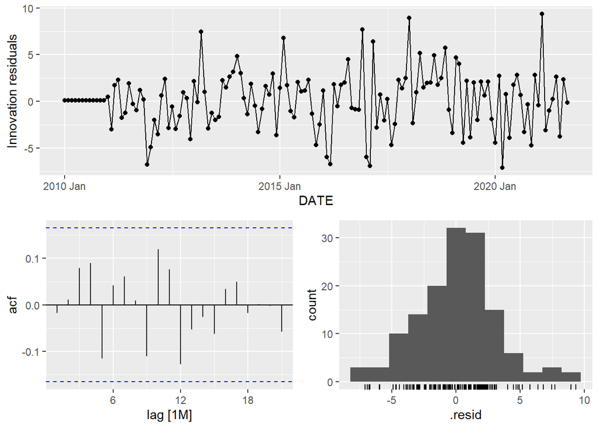

```r
m %>% select(m1) %>% gg_tsresiduals()
```

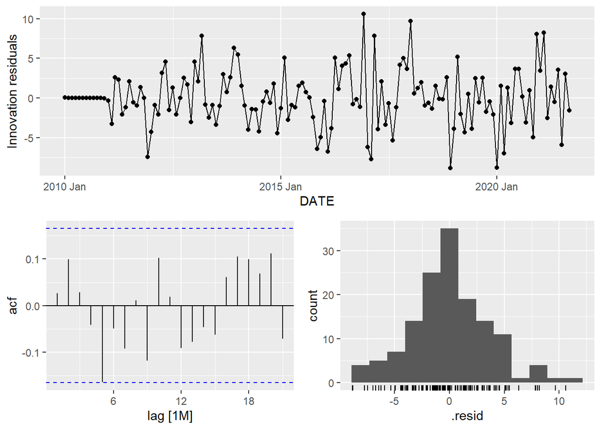

```r
m %>% select(m2) %>% gg_tsresiduals()
```

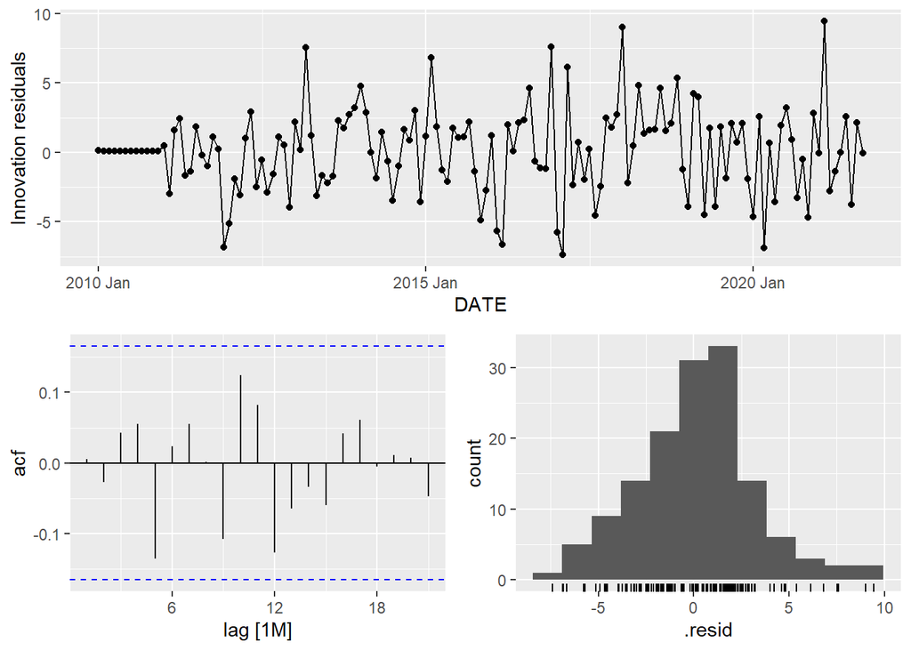

```r
m %>% select(m3) %>% gg_tsresiduals()
```

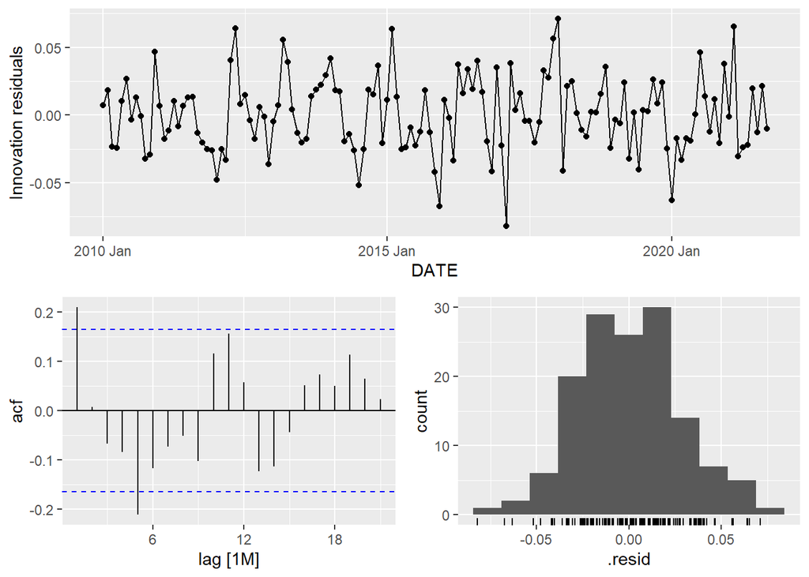

```r
m %>% select(m4) %>% gg_tsresiduals()
```

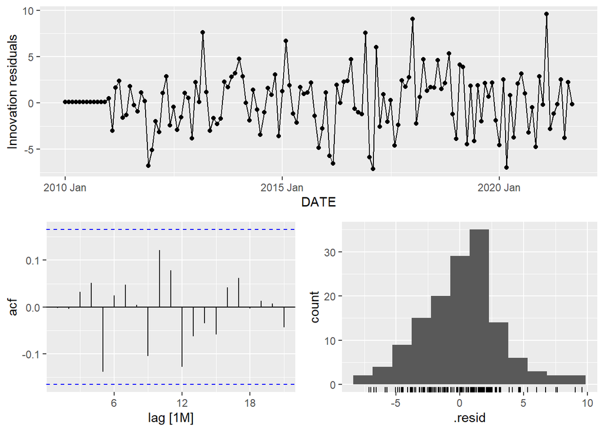

```r
m %>% select(m5) %>% gg_tsresiduals()
```

4. For the set of five models selected (automatically and/or manually) examine the in-sample accuracy metrics. Based on a holistic analysis of the information criteria select the best two ARIMA models and the ETS model. Report the model name/order and their parameter values.

For model cross-validation purposes stretch the DR data as follows:

```r
glance(m)
```

| .model | sigma2 | log_lik | AIC | AICc | BIC | ar_roots | ma_roots | MSE | AMSE | MAE |
| --- | --- | --- | --- | --- | --- | --- | --- | --- | --- | --- |
| m1 | 1.076398e+01 | -337.7641 | 683.5282 | 683.8508 | 694.9675 |  |  | NA | NA | NA |
| m2 | 1.439604e+01 | -351.4630 | 710.9260 | 711.2512 | 722.3341 |  |  | NA | NA | NA |
| m3 | 1.088208e+01 | -337.4004 | 686.8009 | 687.4894 | 703.9597 |  |  | NA | NA | NA |
| m4 | 8.595485e-04 | -494.5760 | 1019.1521 | 1022.9921 | 1063.3834 |  |  | 8.321494 | 9.868938 | 0.02247924 |
| m5 | 1.085846e+01 | -337.2970 | 686.5940 | 687.2825 | 703.7529 |  |  | NA | NA | NA |

5. Fit cross-validation models for each of the time sub-series in the stretched data for each of the four model types selected in (4). In the case(s) where the models were automatically selected, do NOT run the automatic selection under cross validation, instead enter manually the model order/type when you call the ARIMA()/ETS() function.

```r
D.CV <- DR2 %>%
  filter(DATE >= yearmonth("2010 Jan")) %>%
  stretch_tsibble(.init = 36, .step = 1)

mC <- D.CV %>%
  model(A1 = ARIMA(ELEC ~ pdq(2,1,0)),
        A3 = ARIMA(ELEC ~ pdq(2,0,1)),
        MNA = ETS(ELEC ~ error("M") + trend("N") + season("A")))
```

6. Prepare a 24-month ahead forecast foe each of the models fitted in (5) and prepare a plot of MAPE vs months-ahead. Based on the dynamic behavior of cross-validation MAPE discuss which model(s) should be kept/discarded.

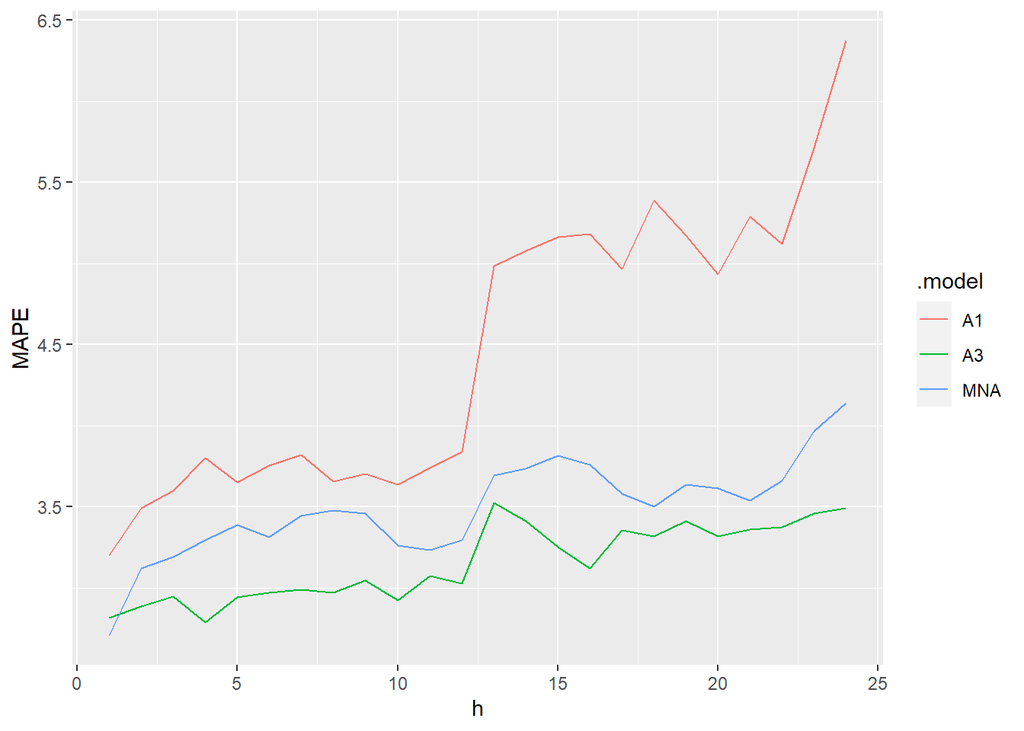

```r
mC %>%
  forecast(h = 24) %>%
  group_by(.id, .model) %>%
  mutate(h = row_number()) %>%
  ungroup() -> fCV

fCV %>%
  accuracy(D, by = c("h", ".model")) %>%
  ggplot(aes(x = h, y = MAPE, color = .model)) +
  geom_line()
```

Since m1 has a outstanding high MAPE, we should discard m1 and keep m3 and ets models.

7. Examine the cross-validation residuals of the models you selected in (6), and based on their correlation (model vs. model) discuss if it is advisable to prepare an ensemble forecast averaging the forecasts of two or more models.

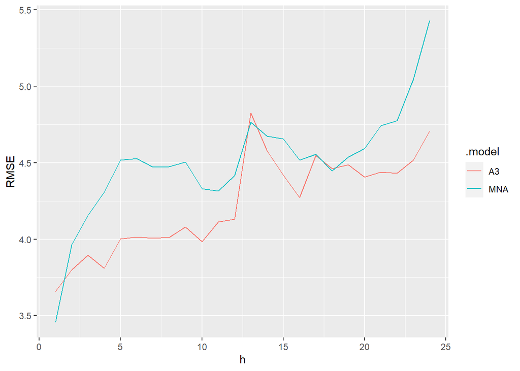

```r
fcv1 <- fCV %>% filter(.model != 'A1')

fcv1 %>%
  accuracy(D, by = c("h", ".model")) %>%
  ggplot(aes(x = h, y = RMSE, color = .model)) +
  geom_line()
```

If the residual errors of the two models are uncorrelated, then covariance is 0. Thus, the variance of the residuals of the ensemble forecast is smaller than the variance of the residuals of either of the two models. However, based on the RMSE, m3 and MNA are correlated in trend. So it is not necessary to have an ensemble model.

8. The index is very useful for energy planning purpose as most of the variability and seasonality is produced by combined cycle natural gas plants and single cycle peaker plants that also run on natural gas (i.e., nuclear and coal generation is fixed and relatively constant). For this purpose it is of interest to know what is the production index level that will not be superated with a probability (service-level) of 95%. For the best model in (6) plot the 24-month ahead forecast and plot the forecast and the corresponding confidence interval to help you address the service level question. Report numerically the month-by-month the index forecasts that meet the desired 95% service level.

```r
f1 <- m %>% select(m3) %>% forecast(h = 24);

f1 %>% hilo(level =c(95)) %>%
  unpack_hilo("95%") %>%
  select("95%_lower", "95%_upper")
```

| 95%_lower | 95%_upper | DATE |
| --- | --- | --- |
| 86.03926 | 98.97032 | 2021 Oct |
| 89.09071 | 102.79130 | 2021 Nov |
| 105.20117 | 119.08179 | 2021 Dec |
| 112.22625 | 126.17237 | 2022 Jan |
| 106.73122 | 120.70563 | 2022 Feb |
| 94.35185 | 108.33919 | 2022 Mar |
| 80.83940 | 94.83275 | 2022 Apr |
| 83.64868 | 97.64485 | 2022 May |
| 95.30640 | 109.30388 | 2022 Jun |
| 105.26013 | 119.25823 | 2022 Jul |

[output cut: 14 more lines]

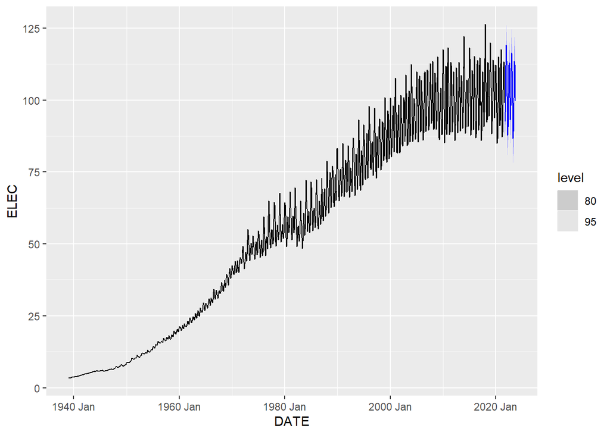

```r
m %>%
  select(m3) %>%
  forecast(h = 24) %>%
  autoplot(D)
```

The best model is ARIMA(2,0,1)(2,1,0).